# SRM img generation

#### *This notebook performs SRM on the brain data to align it into the same space and then runs the same neural net as above to recreate images*

Now lets use SRM to see if we can improve these elementary results using all subs

```python
import brainiak.funcalign.srm
from scipy import stats
from sklearn import svm
import numpy as np
from tqdm import tqdm
import torch
import torch.nn as nn
import pytorch_lightning as pl
from pytorch_lightning.callbacks.early_stopping import EarlyStopping
from pytorch_lightning.callbacks import ModelCheckpoint
import torch.nn.functional as F
from torch.utils.data import TensorDataset, DataLoader
import numpy as np
import argparse
import os
from PIL import Image
import matplotlib.pyplot as plt
from sklearn.feature_selection import SelectKBest
from sklearn.feature_selection import f_classif
```

Load the raw data and run SRM (can take a while). First the train data.

```python
# First SRM is a 2000 feature SRM
features = 2000
# Download if already preprocessed
try:
    all_sub_SRM_train = np.load(f'np_data/{features}_SRM_all_subs_train.npy')
    all_sub_images_train = np.load('np_data/all_sub_images_train.npy')
    all_sub_labels_train = np.load('np_data/all_sub_labels_train.npy')
    all_sub_SRM_test = np.load(f'np_data/{features}_SRM_all_subs_test.npy')
    all_sub_images_test = np.load('np_data/all_sub_images_test.npy')
    all_sub_labels_test = np.load('np_data/all_sub_labels_test.npy')

# Else make the data
except FileNotFoundError:
    for tag in ['train', 'test']:
        # load the data
        num_subs = 3
        labels = []
        fmri = []
        images = []
        for i in range(1, num_subs+1): # Loading the data
            labels.append(np.load(f"np_data/sub_0{i}_labels_{tag}.npy"))
            fmri.append(np.load(f"np_data/sub_0{i}_fmri_{tag}.npy"))
            images.append(np.load(f"np_data/sub_0{i}_images_{tag}.npy"))


        # Data is not sorted. Images where shown in random order. We have to make some alignments.
        for i in range(num_subs):
            indexed_sort = np.argsort(labels[i])
            labels[i] = labels[i][indexed_sort]
            fmri[i] = fmri[i][indexed_sort]
            images[i] = images[i][indexed_sort]

        images = np.array(images)
        labels = np.array(labels)

        # Fmri has differing lengths, have to keep as a list
        # Also, reorganizing to fit SRM
        for subj in range(len(fmri)):
            fmri[subj] = np.transpose(fmri[subj], (1, 0))

        # Create the SRM object
        if tag == 'train':
            srm = brainiak.funcalign.srm.SRM(n_iter=20, features=features)
            print("fitting SRM")
            srm.fit(fmri)
            print("SRM has been fit")

        transformed_data = srm.transform(fmri)
        all_sub_SRM = np.concatenate(np.array(transformed_data), axis = 1)
        all_sub_SRM = stats.zscore(all_sub_SRM, axis = 1)
        all_sub_SRM = np.transpose(all_sub_SRM, (1, 0)) # Turning it back into n * features
        all_sub_images = np.concatenate(images, axis = 0)
        all_sub_labels = np.concatenate(labels, axis = 0)

        # Saving
        np.save(f'np_data/{features}_SRM_all_subs_{tag}.npy', all_sub_SRM)
        np.save(f'np_data/all_sub_images_{tag}.npy', all_sub_images)
        np.save(f'np_data/all_sub_labels_{tag}.npy', all_sub_labels)
```

Reminder that we train and test on the training data because the test data contains unseen classes. This will be useful in our image generation, but it makes testing on it impossible. Further, the way that we sub sample the training data avoids any double dipping.

```python
accuracies = []
train_split = 0.8
# Define the classifier
clf = svm.SVC(gamma = 'auto')


for i in tqdm(range(1000)):
    ss = np.random.randint(1, 1200, size = 2) # taking a subsample of 2 categories
    if ss[0] == ss[1]: # so we don't sample twice the same number
        ss[1] = ss[0]+1
    ss_coords = np.in1d(all_sub_labels_train, ss).nonzero()[0] # getting coords for all occurences of the class
    shuffle = np.random.permutation(len(ss_coords)) # shuffle
    labels_ss = (all_sub_labels_train[ss_coords])
    fmri_ss = (all_sub_SRM_train[ss_coords])

    # keeping the training and test data balanced
    x_len = int(len(labels_ss)*train_split/2) # Number of vals in each class to train on
    mask = np.hstack([np.random.choice(np.where(labels_ss == _class)[0], x_len, replace=False)
                      for _class in np.unique(labels_ss)])

    # Extract
    selected = np.where(~np.in1d(np.arange(len(labels_ss)), mask))[0]
    train_x, train_y = fmri_ss[mask], labels_ss[mask]
    test_x, test_y = fmri_ss[selected], labels_ss[selected]
    clf.fit(train_x, train_y)
    accuracies.extend((clf.predict(test_x) == test_y))

print(f"yielding us {sum(accuracies)/len(accuracies)} in a binary classification task")
```

```
yielding us 0.9781666666666666 in a binary classification task
```

```python
accuracies = []
train_split = 0.8
# Define the classifier
clf = svm.SVC(gamma = 'auto')
all_sub_SRM_train = np.load('np_data/1000_SRM_all_subs_train.npy')

for i in tqdm(range(1000)):
    ss = np.random.randint(1, 1200, size = 2) # taking a subsample of 2 categories
    if ss[0] == ss[1]: # so we don't sample twice the same number
        ss[1] = ss[0]+1
    ss_coords = np.in1d(all_sub_labels_train, ss).nonzero()[0] # getting coords for all occurences of the class
    shuffle = np.random.permutation(len(ss_coords)) # shuffle
    labels_ss = (all_sub_labels_train[ss_coords])
    fmri_ss = (all_sub_SRM_train[ss_coords])

    # keeping the training and test data balanced
    x_len = int(len(labels_ss)*train_split/2) # Number of vals in each class to train on
    mask = np.hstack([np.random.choice(np.where(labels_ss == _class)[0], x_len, replace=False)
                      for _class in np.unique(labels_ss)])

    # Extract
    selected = np.where(~np.in1d(np.arange(len(labels_ss)), mask))[0]
    train_x, train_y = fmri_ss[mask], labels_ss[mask]
    test_x, test_y = fmri_ss[selected], labels_ss[selected]
    clf.fit(train_x, train_y)
    accuracies.extend((clf.predict(test_x) == test_y))

print(f"yielding us {sum(accuracies)/len(accuracies)} in a binary classification task")
```

```
yielding us 0.9673333333333334 in a binary classification task
```

We get better classification accuracy when using a larger SRM 2000 vs 1000. For now we will work with a feature space of 2000. This may need to be adjusted in the future however.

We are going to do one more thing, which is feature extraciton on our 2000 feature SRM. This will be useful in future notebooks.

```python
extractor = SelectKBest(f_classif, k=300)
SRM_train_new = extractor.fit_transform(all_sub_SRM_train, all_sub_labels_train)
SRM_test_new = extractor.transform(all_sub_SRM_test)
np.save('np_data/300_SRM_all_subs_train.npy', SRM_train_new)
np.save('np_data/300_SRM_all_subs_test.npy', SRM_test_new)
```

Let's see how we go with this data.

```python
accuracies = []
train_split = 0.8
# Define the classifier
clf = svm.SVC(gamma = 'auto')

for i in tqdm(range(1000)):
    ss = np.random.randint(1, 1200, size = 2) # taking a subsample of 2 categories
    if ss[0] == ss[1]: # so we don't sample twice the same number
        ss[1] = ss[0]+1
    ss_coords = np.in1d(all_sub_labels_train, ss).nonzero()[0] # getting coords for all occurences of the class
    shuffle = np.random.permutation(len(ss_coords)) # shuffle
    labels_ss = (all_sub_labels_train[ss_coords])
    fmri_ss = (SRM_train_new[ss_coords])

    # keeping the training and test data balanced
    x_len = int(len(labels_ss)*train_split/2) # Number of vals in each class to train on
    mask = np.hstack([np.random.choice(np.where(labels_ss == _class)[0], x_len, replace=False)
                      for _class in np.unique(labels_ss)])

    # Extract
    selected = np.where(~np.in1d(np.arange(len(labels_ss)), mask))[0]
    train_x, train_y = fmri_ss[mask], labels_ss[mask]
    test_x, test_y = fmri_ss[selected], labels_ss[selected]
    clf.fit(train_x, train_y)
    accuracies.extend((clf.predict(test_x) == test_y))

print(f"yielding us {sum(accuracies)/len(accuracies)} in a binary classification task")
```

```
yielding us 0.9638333333333333 in a binary classification task
```

Regardless, we have to soldier on!

### Running the img generation task

This entails reusing the pytorch lightning architecture from the former question.

```python
class DataModule(pl.LightningDataModule):
    @staticmethod
    def get_HP(args = []):
        parser = argparse.ArgumentParser(description='Define model Hyperparams')
        root_dir = os.getcwd()
        parser.add_argument('--embed_size', default = 300)
        parser.add_argument('--X_train', default=os.path.join(root_dir, 'np_data/300_SRM_all_subs_train.npy'), type=str)
        parser.add_argument('--X_test', default=os.path.join(root_dir, 'np_data/300_SRM_all_subs_test.npy'), type=str)
        parser.add_argument('--y_train', default=os.path.join(root_dir, 'np_data/all_sub_images_train.npy'), type=str)
        parser.add_argument('--y_test', default=os.path.join(root_dir, 'np_data/all_sub_images_test.npy'), type=str)
        parser.add_argument('--data_dir', default=os.path.join(root_dir, 'data/SRM_gen'), type=str)
        return parser.parse_args(args = args)

    def __init__(self, HP):
        super().__init__()
        self.HP = HP

    # For one time preprocessing of data
    def prepare_data(self):
        try: # Check if the data has already been preprocessed
            temp = torch.load(self.HP.data_dir + '/test.h5'); del temp;
        except:
            X_train = np.load(self.HP.X_train)
            y_train = np.load(self.HP.y_train)
            X_test = np.load(self.HP.X_test)
            y_test = np.load(self.HP.y_test)

            # Creating the dataset
            X_train = torch.reshape(torch.Tensor(X_train), (-1, self.HP.embed_size, 1, 1)) # transform to torch tensor# transform to torch tensor
            X_test = torch.reshape(torch.Tensor(X_test), (-1, self.HP.embed_size, 1, 1))

            #ims train
            y_train_resized = []
            for img in y_train:
                img = Image.fromarray(img)
                img = img.resize((32, 32), Image.BICUBIC)
                y_train_resized.append(np.array(img).transpose(2, 0, 1))
            y_train = torch.Tensor(np.stack(y_train_resized, axis=0))/255

            #ims test
            y_test_resized = []
            for img in y_test:
                img = Image.fromarray(img)
                img = img.resize((32, 32), Image.BICUBIC)
                y_test_resized.append(np.array(img).transpose(2, 0, 1))
            y_test = torch.Tensor(np.stack(y_test_resized, axis=0))/255
            if not os.path.exists(self.HP.data_dir):
                os.mkdir(self.HP.data_dir)
            torch.save({"X": X_train, "y": y_train}, self.HP.data_dir + '/train.h5')
            torch.save({"X": X_test, "y": y_test}, self.HP.data_dir + '/test.h5')

    def setup(self, stage=None):
        train = torch.load(self.HP.data_dir + '/train.h5')
        self.train_ds = TensorDataset(train["X"], train["y"])
        test = torch.load(self.HP.data_dir + '/test.h5')
        self.test_ds = TensorDataset(test["X"], test["y"])

    def train_dataloader(self):
        return DataLoader(self.train_ds, batch_size=64, pin_memory=True, shuffle=True) # create your dataloader

    def val_dataloader(self):
        return DataLoader(self.test_ds, batch_size=64, shuffle=True) # create your dataloader)

    def test_dataloader(self):
        return DataLoader(self.test_ds, batch_size=10, shuffle=True) # create your dataloader)



class Generator(pl.LightningModule):
    @staticmethod
    def get_HP(args = []):
        parser = argparse.ArgumentParser(description='Define model Hyperparams')
        root_dir = os.getcwd()
        parser.add_argument('--embed_size', default = 300)
        parser.add_argument('--ngf', default = 64)
        return parser.parse_args(args = args)

    def __init__(self, HP):
        super().__init__()
        self.HP = HP
        self.save_hyperparameters()
        self.main = nn.Sequential(
            # input is Z, going into a convolution
            nn.ConvTranspose2d(HP.embed_size, HP.ngf * 8, 4, 1, 0, bias=False),
            nn.BatchNorm2d(HP.ngf * 8),
            nn.ReLU(True),
            # state size. (ngf*8) x 4 x 4
            nn.ConvTranspose2d(HP.ngf * 8, HP.ngf * 4, 4, 2, 1, bias=False),
            nn.BatchNorm2d(HP.ngf * 4),
            nn.ReLU(True),
            # state size. (ngf*4) x 8 x 8
            nn.ConvTranspose2d(HP.ngf * 4, HP.ngf * 2, 4, 2, 1, bias=False),
            nn.BatchNorm2d(HP.ngf * 2),
            nn.ReLU(True),
            # state size. (ngf*2) x 16 x 16
            nn.ConvTranspose2d(HP.ngf * 2, HP.ngf, 4, 2, 1, bias=False),
            nn.BatchNorm2d(HP.ngf),
            nn.ReLU(True),
            nn.ConvTranspose2d(HP.ngf, 3, kernel_size=1, stride=1, padding=0, bias=False),
            nn.Sigmoid()
        )

    def configure_optimizers(self):
        optimizer = torch.optim.Adam(self.parameters(), lr=1e-3)
        return optimizer

    def forward(self, x):
        return self.main(x)

    def training_step(self, batch, batch_idx):
        fmri, ims = batch
        gen = self(fmri)
        loss = F.mse_loss(gen, ims)
        self.log('train_loss', loss, )
        return loss

    def validation_step(self, batch, batch_idx):
        fmri, ims = batch
        gen = self(fmri)
        loss = F.mse_loss(gen, ims)
        self.log('val_loss', loss, prog_bar=True)

    def test_step(self, batch, batch_idx):
        fmri, ims = batch
        gen = self(fmri)
        loss = F.mse_loss(gen, ims)
        self.predictions = gen
        self.targets = ims
        self.log('test_loss', loss)


early_stop_callback = EarlyStopping(
   monitor='train_loss',
   min_delta=0,
   patience=30,
   verbose=False,
   mode='min'
)

# saves a file like: my/path/sample-mnist-epoch=02-val_loss=0.32.ckpt
checkpoint_callback = ModelCheckpoint(
    save_last=True,
    save_top_k=1,
    mode='min',
    monitor='train_loss',
    filename='nueroImg-{epoch:02d}-{train_loss:.4f}'
)

dm_HP = DataModule.get_HP()
dm = DataModule(dm_HP)

"""
Running our model
"""
model_HP = Generator.get_HP()
model = Generator(model_HP)

trainer = pl.Trainer(max_epochs=200, gpus=1, callbacks=[checkpoint_callback, early_stop_callback])
trainer.fit(model, dm)
```

```
GPU available: True, used: True
TPU available: False, using: 0 TPU cores
LOCAL_RANK: 0 - CUDA_VISIBLE_DEVICES: [0,1]
Set SLURM handle signals.

  | Name | Type       | Params
------------------------------------
0 | main | Sequential | 5.2 M
------------------------------------
5.2 M     Trainable params
0         Non-trainable params
5.2 M     Total params
20.849    Total estimated model params size (MB)
```

```
Saving latest checkpoint...
```

```
1
```

```
LOCAL_RANK: 0 - CUDA_VISIBLE_DEVICES: [0,1]
```

```
--------------------------------------------------------------------------------
DATALOADER:0 TEST RESULTS
{'test_loss': 0.0981568768620491}
--------------------------------------------------------------------------------
generated ims on the left, real ims on the right
```

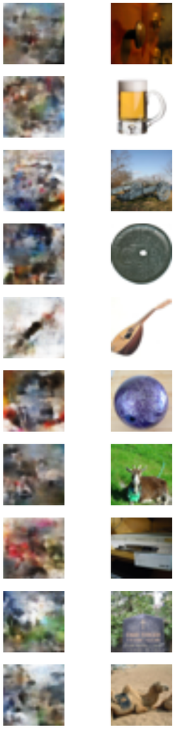

```python
# This will generate prediction and target pairs
v_num = model.get_progress_bar_dict()['v_num']
trainer.test(model=model, ckpt_path=f'lightning_logs/version_{v_num}/checkpoints/last.ckpt')
predictions = model.predictions
targets = model.targets

targets = np.transpose(targets.cpu().numpy(), (0, 2, 3, 1))
predictions = np.transpose(predictions.cpu().numpy(), (0, 2, 3, 1))

R = 10
C = 2
print("generated ims on the left, real ims on the right")
plt.figure(figsize=(8, 30), dpi=80)
for i in range(10):
    plt.subplot(R, C, i*2 + 1)
    plt.imshow(predictions[i], interpolation='bilinear')
    plt.axis('off')
    plt.subplot(R, C, i*2 + 2)
    plt.imshow(targets[i], interpolation='bilinear')
    plt.axis('off')
plt.show()
```

This looks much better than our previous generator. For example the guitar is almost recognizable. We are getting a lot more color and even some matching shapes after 100 epochs of training. Next step is to try to realize our generations and perform a more exhaustive search. A step in the right direction!